# Question

A spinner was constructed:

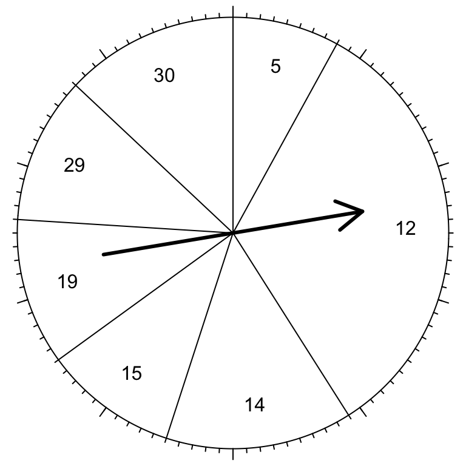

The spinner’s probability distribution is shown below.

| $x$ | $\mathbb{P}[x]$ |
| --- | --- |
| 5 | 0.08 |
| 12 | 0.33 |
| 14 | 0.14 |
| 15 | 0.10 |
| 19 | 0.11 |
| 29 | 0.11 |
| 30 | 0.13 |

## Answerlist

- What is the probability of spinning 30? In other words, what is $\mathbb{P}[X=30]$?
- What is the probability of spinning 12 or 19? In other words, what is $\mathbb{P}[X=12 ~\text{ or }~ X=19]$?
- If spinning twice, what is the probability of first spinning 12 and then spinning 19? In other words, what is $\mathbb{P}[X_1=12 ~\text{ and }~ X_2=19]$?
- What is the probability of spinning at least 29? In other words, what is $\mathbb{P}[X\ge 29]$?
- Determine the mean of the probability distribution by using $\mu = \sum x\cdot \mathbb{P}[x]$.
- Determine the standard deviation of the probability distribution by using $\sigma = \sqrt{\sum (x-\mu)^2 \cdot \mathbb{P}[x]}$.

# Solution

[video](https://vimeo.com/531915788)

Make a table (for parts mean and standard deviation).

| $x$ | $\mathbb{P}[x]$ | $x\cdot\mathbb{P}[x]$ | $x-\mu$ | $(x-\mu)^2$ | $(x-\mu)^2 \cdot \mathbb{P}[x]$ |
| --- | --- | --- | --- | --- | --- |
| 5 | 0.08 | 0.4 | -12 | 144 | 11.52 |
| 12 | 0.33 | 3.96 | -5 | 25 | 8.25 |
| 14 | 0.14 | 1.96 | -3 | 9 | 1.26 |
| 15 | 0.1 | 1.5 | -2 | 4 | 0.4 |
| 19 | 0.11 | 2.09 | 2 | 4 | 0.44 |
| 29 | 0.11 | 3.19 | 12 | 144 | 15.84 |
| 30 | 0.13 | 3.9 | 13 | 169 | 21.97 |
|  |  | $\sum x \cdot \mathbb{P}[x]=17.00$ |  |  | $\sigma^2=59.68$ |
|  |  | $\mu = 17.00$ |  |  | $\sigma=7.73$ |

## Answerlist

- 0.13
- $0.33 + 0.11$ = **0.44**
- $0.33 \times 0.11$ = **0.0363**
- 0.24
- $\mu = 17$
- $\sigma = 7.7252832$

# Meta-information

extype: cloze exsolution: 0.13|0.44|0.0363|0.24|17|7.7252832| exclozetype: num|num|num|num|num|num exname: probdist extol: 0.01 exextra[numwidth,logical]: TRUE